# Vanilla CNN and Fine-Tune VGG16 - for Dogs and Cats Classificationn

**Student Name & ID**  
*Abdur Rahman Shaik-89941778*

# 1 Obtain Data

```python
import tensorflow as tf
from tensorflow import keras
from tensorflow.keras import layers
import pathlib
from tensorflow.keras.utils import image_dataset_from_directory
import matplotlib.pyplot as plt
```

```python
import os, shutil, pathlib

original_dir = pathlib.Path("C://Users//Alienware//Downloads//catsndogs//data//train//train")
new_base_dir = pathlib.Path("../data/kaggle_dogs_vs_cats_small")

def make_subset(subset_name, start_index, end_index):
    for category in ("cat", "dog"):
        dir = new_base_dir / subset_name / category
        os.makedirs(dir)
        fnames = [f"{category}.{i}.jpg" for i in range(start_index, end_index)]
        for fname in fnames:
            shutil.copyfile(src=original_dir / fname,
                            dst=dir / fname)

make_subset("train", start_index=0, end_index=1000)
make_subset("validation", start_index=1000, end_index=1500)
make_subset("test", start_index=1500, end_index=2500)
```

```python
# Set image properties
BATCH_SIZE = 32
IMAGE_SIZE = (180, 180)

# Load train dataset
train_dataset = image_dataset_from_directory(
    new_base_dir / "train",
    image_size=IMAGE_SIZE,
    batch_size=BATCH_SIZE,
    shuffle=True,
    seed=42
)

# Load validation dataset
validation_dataset = image_dataset_from_directory(
    new_base_dir / "validation",
    image_size=IMAGE_SIZE,
    batch_size=BATCH_SIZE,
    shuffle=True,
    seed=42
)

# Load test dataset
test_dataset = image_dataset_from_directory(
    new_base_dir / "test",
    image_size=IMAGE_SIZE,
    batch_size=BATCH_SIZE,
    shuffle=False
)
```

```
Found 2000 files belonging to 2 classes.
Found 1000 files belonging to 2 classes.
Found 2000 files belonging to 2 classes.
```

# 2. EDA:

```
Train - Cats: 1000, Dogs: 1000
Validation - Cats: 500, Dogs: 500
Test - Cats: 1000, Dogs: 1000
Sample Cat Images from Training Set
```

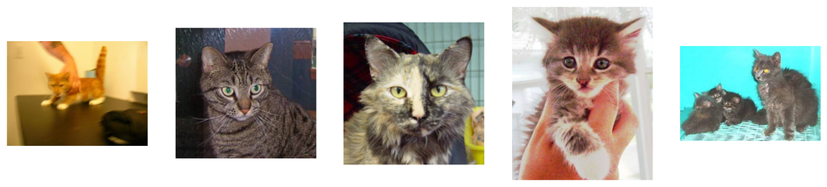

```
Sample Dog Images from Training Set
```

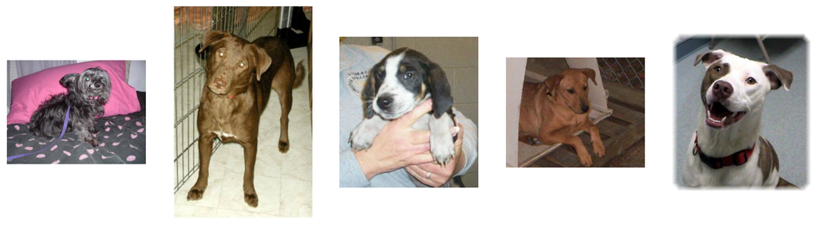

```
Sample Cat Images from Validation Set
```

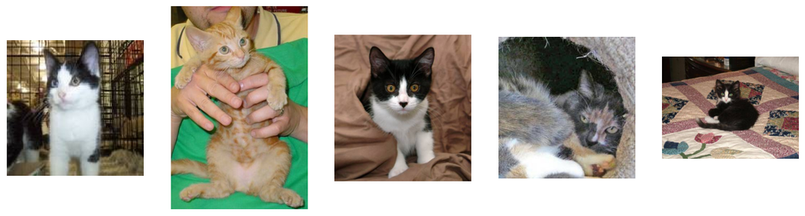

```
Sample Dog Images from Validation Set
```

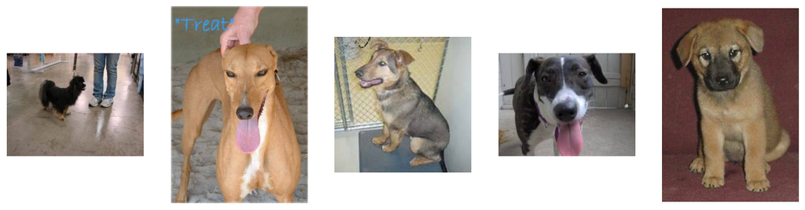

```
Sample Cat Images from Test Set
```

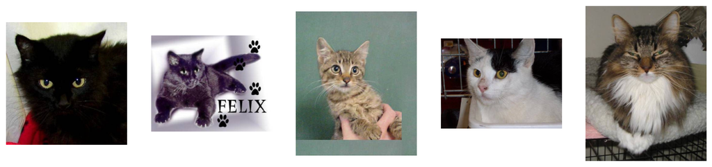

```
Sample Dog Images from Test Set
```

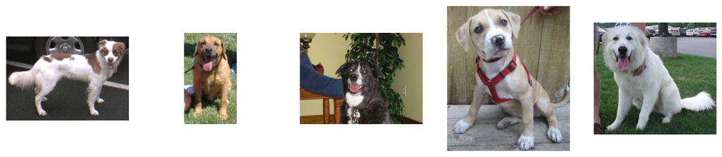

```python
import os
import matplotlib.pyplot as plt
from PIL import Image

# Directories for each dataset
train_dir = '../data/kaggle_dogs_vs_cats_small/train'
val_dir = '../data/kaggle_dogs_vs_cats_small/validation'
test_dir = '../data/kaggle_dogs_vs_cats_small/test'

# Check the distribution of classes in the three datasets
train_cats = len(os.listdir(f"{train_dir}/cat"))
train_dogs = len(os.listdir(f"{train_dir}/dog"))

val_cats = len(os.listdir(f"{val_dir}/cat"))
val_dogs = len(os.listdir(f"{val_dir}/dog"))

test_cats = len(os.listdir(f"{test_dir}/cat"))
test_dogs = len(os.listdir(f"{test_dir}/dog"))

print(f"Train - Cats: {train_cats}, Dogs: {train_dogs}")
print(f"Validation - Cats: {val_cats}, Dogs: {val_dogs}")
print(f"Test - Cats: {test_cats}, Dogs: {test_dogs}")

# Visualize some images from each dataset
def plot_images(path, n=5):
    files = os.listdir(path)[:n]  # Take the first n files
    fig, axs = plt.subplots(1, n, figsize=(15, 5))
    for i, file in enumerate(files):
        img = Image.open(os.path.join(path, file))
        axs[i].imshow(img)
        axs[i].axis("off")
    plt.show()

# Show some images of cats and dogs from each dataset
print("Sample Cat Images from Training Set")
plot_images(f"{train_dir}/cat")

print("Sample Dog Images from Training Set")
plot_images(f"{train_dir}/dog")

print("Sample Cat Images from Validation Set")
plot_images(f"{val_dir}/cat")

print("Sample Dog Images from Validation Set")
plot_images(f"{val_dir}/dog")

print("Sample Cat Images from Test Set")
plot_images(f"{test_dir}/cat")

print("Sample Dog Images from Test Set")
plot_images(f"{test_dir}/dog")
```

```python
import tensorflow as tf  # ensure TensorFlow is imported

# image statistics
def analyze_image_statistics(dataset):
    pixel_mean = []
    pixel_std = []
    # The dataset yields (images, labels)
    for images, _ in dataset:
        pixel_mean.append(tf.reduce_mean(images))
        pixel_std.append(tf.math.reduce_std(images))

    return {
        'mean': tf.reduce_mean(pixel_mean),
        'std': tf.reduce_mean(pixel_std)
    }

# Use the dataset object obtained from image_dataset_from_directory
stats = analyze_image_statistics(train_dataset)
print("\nImage Statistics:")
print(f"Mean pixel value: {stats['mean']:.2f}")
print(f"Std pixel value: {stats['std']:.2f}")
```

```
Image Statistics:
Mean pixel value: 114.03
Std pixel value: 65.50
```

```
Class names: ['cat', 'dog']

Images per class in training set: {'cat': 1000, 'dog': 1000}
```

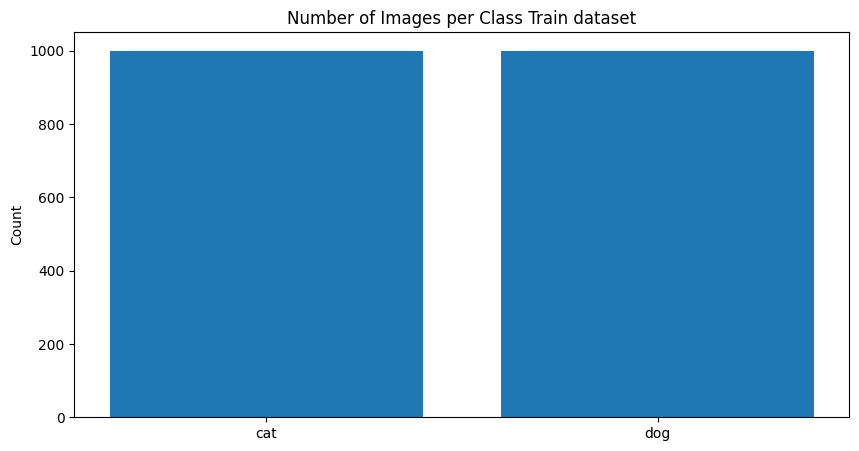

```python
# class names
class_names = train_dataset.class_names
print("\nClass names:", class_names)

# image counts
def count_images_per_class(dataset):
    counts = {name: 0 for name in class_names}
    for images, labels in dataset:
        for label in labels:
            counts[class_names[label.numpy()]] += 1
    return counts

train_counts = count_images_per_class(train_dataset)
print("\nImages per class in training set:", train_counts)

# show images
plt.figure(figsize=(10, 5))
plt.bar(class_names, list(train_counts.values()))
plt.title('Number of Images per Class Train dataset')
plt.ylabel('Count')
plt.show()
```

### Summary:

- Se tiene la siguiente distribucion de la data:
  - Train - Cats: 1000, Dogs: 1000
  - Validation - Cats: 500, Dogs: 500
  - Test - Cats: 1000, Dogs: 1000
  - Sample Cat Images from Training Set
- Para la data de train se tiene:
- Mean pixel value: 114.03
- Std pixel value: 65.50

# 3 Train two networks

## 3.1 Define a Neural Network - Convnet From Scratch

### Definning the model

```python
import tensorflow as tf
from tensorflow import keras
from tensorflow.keras import layers

# Define the input
inputs = keras.Input(shape=(180, 180, 3))

# Rescaling the image pixels (normalization)
x = layers.Rescaling(1./255)(inputs)

# First convolutional layer (32 filters, 3x3 kernel, ReLU activation)
x = layers.Conv2D(filters=32, kernel_size=3, activation="relu")(x)
x = layers.MaxPooling2D(pool_size=2)(x)

# Second convolutional layer (64 filters, 3x3 kernel, ReLU activation)
x = layers.Conv2D(filters=64, kernel_size=3, activation="relu")(x)
x = layers.MaxPooling2D(pool_size=2)(x)

# Third convolutional layer (128 filters, 3x3 kernel, ReLU activation)
x = layers.Conv2D(filters=128, kernel_size=3, activation="relu")(x)
x = layers.MaxPooling2D(pool_size=2)(x)

# Fourth convolutional layer (256 filters, 3x3 kernel, ReLU activation)
x = layers.Conv2D(filters=256, kernel_size=3, activation="relu")(x)
x = layers.MaxPooling2D(pool_size=2)(x)

# Flatten layer to convert 2D matrix to a 1D vector
x = layers.Flatten()(x)

# Dropout layer to prevent overfitting (regularization)
x = layers.Dropout(0.5)(x)

# Output layer with 1 neuron (binary classification) and sigmoid activation
outputs = layers.Dense(1, activation="sigmoid")(x)

# Create the model
model = keras.Model(inputs=inputs, outputs=outputs)

# Display the model summary
model.summary()
```

```
Model: "model"
_________________________________________________________________
 Layer (type)                Output Shape              Param #
=================================================================
 input_1 (InputLayer)        [(None, 180, 180, 3)]     0

 rescaling (Rescaling)       (None, 180, 180, 3)       0

 conv2d (Conv2D)             (None, 178, 178, 32)      896

 max_pooling2d (MaxPooling2D  (None, 89, 89, 32)       0
 )

 conv2d_1 (Conv2D)           (None, 87, 87, 64)        18496

 max_pooling2d_1 (MaxPooling  (None, 43, 43, 64)       0
 2D)
_________________________________________________________________
 Layer (type)                Output Shape              Param #
=================================================================
 input_1 (InputLayer)        [(None, 180, 180, 3)]     0

 rescaling (Rescaling)       (None, 180, 180, 3)       0

 conv2d (Conv2D)             (None, 178, 178, 32)      896

 max_pooling2d (MaxPooling2D  (None, 89, 89, 32)       0
 )

 conv2d_1 (Conv2D)           (None, 87, 87, 64)        18496

 max_pooling2d_1 (MaxPooling  (None, 43, 43, 64)       0
 2D)

 conv2d_2 (Conv2D)           (None, 41, 41, 128)       73856

 max_pooling2d_2 (MaxPooling  (None, 20, 20, 128)      0
 2D)

 conv2d_3 (Conv2D)           (None, 18, 18, 256)       295168

 max_pooling2d_3 (MaxPooling  (None, 9, 9, 256)        0
 2D)

 flatten (Flatten)           (None, 20736)             0

 dropout (Dropout)           (None, 20736)             0

 dense (Dense)               (None, 1)                 20737

=================================================================
Total params: 409,153
Trainable params: 409,153
Non-trainable params: 0
_________________________________________________________________
```

```python
model.compile(loss="binary_crossentropy",
              optimizer="rmsprop",
              metrics=["accuracy"])
```

### Trainning the model

```python
callbacks = [
    keras.callbacks.ModelCheckpoint(
        filepath="./models/convnet_from_scratch.keras",
        save_best_only=True,
        monitor="val_loss")
]
history = model.fit(
    train_dataset,
    epochs=30,
    validation_data=validation_dataset,
    callbacks=callbacks)
```

### **Displaying curves of loss and accuracy during training**

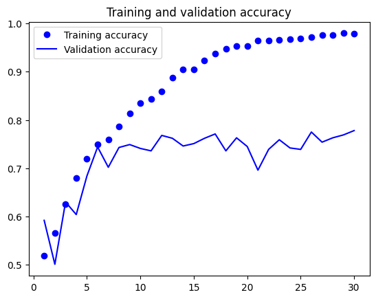

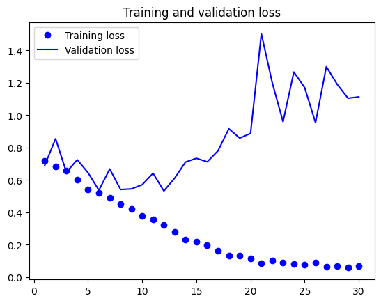

```python
accuracy = history.history["accuracy"]
val_accuracy = history.history["val_accuracy"]
loss = history.history["loss"]
val_loss = history.history["val_loss"]
epochs = range(1, len(accuracy) + 1)
plt.plot(epochs, accuracy, "bo", label="Training accuracy")
plt.plot(epochs, val_accuracy, "b", label="Validation accuracy")
plt.title("Training and validation accuracy")
plt.legend()
plt.figure()
plt.plot(epochs, loss, "bo", label="Training loss")
plt.plot(epochs, val_loss, "b", label="Validation loss")
plt.title("Training and validation loss")
plt.legend()
plt.show()
```

### **Evaluating the model on the test set**

```python
test_model = keras.models.load_model("./models/convnet_from_scratch.keras")
test_loss, test_acc = test_model.evaluate(test_dataset)
print(f"Test accuracy: {test_acc:.3f}")
```

```
Test accuracy: 0.746
```

## 3.2 Fine-Tune VGG16

### 3.2.1 **Instantiating the VGG16 convolutional base**

```python
from tensorflow import keras
from tensorflow.keras import layers
import pathlib
from tensorflow.keras.utils import image_dataset_from_directory
```

```python
conv_base = keras.applications.vgg16.VGG16(
    weights="imagenet",
    include_top=False,
    input_shape=(180, 180, 3))
```

```
Downloading data from https://storage.googleapis.com/tensorflow/keras-applications/vgg16/vgg16_weights_tf_dim_ordering_tf_kernels_notop.h5
```

```python
conv_base.summary()
```

```
Model: "vgg16"
_________________________________________________________________
 Layer (type)                Output Shape              Param #
=================================================================
 input_2 (InputLayer)        [(None, 180, 180, 3)]     0
_________________________________________________________________
 Layer (type)                Output Shape              Param #
=================================================================
 input_2 (InputLayer)        [(None, 180, 180, 3)]     0

 block1_conv1 (Conv2D)       (None, 180, 180, 64)      1792

 block1_conv2 (Conv2D)       (None, 180, 180, 64)      36928

 block1_pool (MaxPooling2D)  (None, 90, 90, 64)        0

 block2_conv1 (Conv2D)       (None, 90, 90, 128)       73856

 block2_conv2 (Conv2D)       (None, 90, 90, 128)       147584

 block2_pool (MaxPooling2D)  (None, 45, 45, 128)       0

 block3_conv1 (Conv2D)       (None, 45, 45, 256)       295168

 block3_conv2 (Conv2D)       (None, 45, 45, 256)       590080

 block3_conv3 (Conv2D)       (None, 45, 45, 256)       590080

 block3_pool (MaxPooling2D)  (None, 22, 22, 256)       0

 block4_conv1 (Conv2D)       (None, 22, 22, 512)       1180160

 block4_conv2 (Conv2D)       (None, 22, 22, 512)       2359808

 block4_conv3 (Conv2D)       (None, 22, 22, 512)       2359808

 block4_pool (MaxPooling2D)  (None, 11, 11, 512)       0

 block5_conv1 (Conv2D)       (None, 11, 11, 512)       2359808

 block5_conv2 (Conv2D)       (None, 11, 11, 512)       2359808

 block5_conv3 (Conv2D)       (None, 11, 11, 512)       2359808

 block5_pool (MaxPooling2D)  (None, 5, 5, 512)         0

=================================================================
Total params: 14,714,688
Trainable params: 14,714,688
Non-trainable params: 0
_________________________________________________________________
```

### 3.2.2 Fast feature extraction without data augmentation

**Extracting the VGG16 features and corresponding labels**

Note: running the following cell on a CPU will take about 10 minutes

```python
import numpy as np

def get_features_and_labels(dataset):
    all_features = []
    all_labels = []
    for images, labels in dataset:
        preprocessed_images = keras.applications.vgg16.preprocess_input(images)
        features = conv_base.predict(preprocessed_images)
        all_features.append(features)
        all_labels.append(labels)
    return np.concatenate(all_features), np.concatenate(all_labels)

train_features, train_labels =  get_features_and_labels(train_dataset)
val_features, val_labels =  get_features_and_labels(validation_dataset)
test_features, test_labels =  get_features_and_labels(test_dataset)
```

```python
train_features.shape
```

```
(2000, 5, 5, 512)
```

**Defining and training the densely connected classifier**

Here we define a new dense neural networks, of only two (neuronal/trainable) layers.

```python
inputs = keras.Input(shape=(5, 5, 512))
x = layers.Flatten()(inputs)
x = layers.Dense(256)(x)
x = layers.Dropout(0.5)(x)
outputs = layers.Dense(1, activation="sigmoid")(x)
model = keras.Model(inputs, outputs)
```

```python
model.summary()
```

```
Model: "model_1"
_________________________________________________________________
 Layer (type)                Output Shape              Param #
=================================================================
 input_3 (InputLayer)        [(None, 5, 5, 512)]       0

 flatten_1 (Flatten)         (None, 12800)             0

 dense_1 (Dense)             (None, 256)               3277056

 dropout_1 (Dropout)         (None, 256)               0

 dense_2 (Dense)             (None, 1)                 257

=================================================================
_________________________________________________________________
 Layer (type)                Output Shape              Param #
=================================================================
 input_3 (InputLayer)        [(None, 5, 5, 512)]       0

 flatten_1 (Flatten)         (None, 12800)             0

 dense_1 (Dense)             (None, 256)               3277056

 dropout_1 (Dropout)         (None, 256)               0

 dense_2 (Dense)             (None, 1)                 257

=================================================================
Total params: 3,277,313
Trainable params: 3,277,313
Non-trainable params: 0
_________________________________________________________________
```

```python
model.compile(loss="binary_crossentropy",
              optimizer="rmsprop",
              metrics=["accuracy"])

callbacks = [
    keras.callbacks.ModelCheckpoint(
      filepath="./models/feature_extraction.keras",
      save_best_only=True,
      monitor="val_loss")
]
history = model.fit(
    train_features, train_labels,
    epochs=20,
    validation_data=(val_features, val_labels),
    callbacks=callbacks)
```

**Plotting the results**

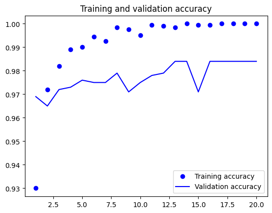

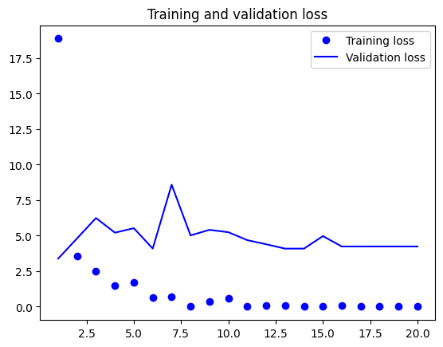

```python
import matplotlib.pyplot as plt
acc = history.history["accuracy"]
val_acc = history.history["val_accuracy"]
loss = history.history["loss"]
val_loss = history.history["val_loss"]
epochs = range(1, len(acc) + 1)
plt.plot(epochs, acc, "bo", label="Training accuracy")
plt.plot(epochs, val_acc, "b", label="Validation accuracy")
plt.title("Training and validation accuracy")
plt.legend()
plt.figure()
plt.plot(epochs, loss, "bo", label="Training loss")
plt.plot(epochs, val_loss, "b", label="Validation loss")
plt.title("Training and validation loss")
plt.legend()
plt.show()
```

```python
test_model = keras.models.load_model(
    "./models/feature_extraction.keras")
test_loss, test_acc = test_model.evaluate(x=test_features, y=test_labels)
print(f"Test accuracy: {test_acc:.3f}")
```

```
Test accuracy: 0.963
```

### 3.2.3 Feature extraction together with data augmentation

**Instantiating and freezing the VGG16 convolutional base**

```python
conv_base  = keras.applications.vgg16.VGG16(
    weights="imagenet",
    include_top=False)
```

```python
conv_base.summary()
```

```
Model: "vgg16"
_________________________________________________________________
 Layer (type)                Output Shape              Param #
=================================================================
 input_4 (InputLayer)        [(None, None, None, 3)]   0

 block1_conv1 (Conv2D)       (None, None, None, 64)    1792

 block1_conv2 (Conv2D)       (None, None, None, 64)    36928

 block1_pool (MaxPooling2D)  (None, None, None, 64)    0

 block2_conv1 (Conv2D)       (None, None, None, 128)   73856

 block2_conv2 (Conv2D)       (None, None, None, 128)   147584

_________________________________________________________________
 Layer (type)                Output Shape              Param #
=================================================================
 input_4 (InputLayer)        [(None, None, None, 3)]   0

 block1_conv1 (Conv2D)       (None, None, None, 64)    1792

 block1_conv2 (Conv2D)       (None, None, None, 64)    36928

 block1_pool (MaxPooling2D)  (None, None, None, 64)    0

 block2_conv1 (Conv2D)       (None, None, None, 128)   73856

 block2_conv2 (Conv2D)       (None, None, None, 128)   147584

 block2_pool (MaxPooling2D)  (None, None, None, 128)   0

 block3_conv1 (Conv2D)       (None, None, None, 256)   295168

 block3_conv2 (Conv2D)       (None, None, None, 256)   590080

 block3_conv3 (Conv2D)       (None, None, None, 256)   590080

 block3_pool (MaxPooling2D)  (None, None, None, 256)   0

 block4_conv1 (Conv2D)       (None, None, None, 512)   1180160

 block4_conv2 (Conv2D)       (None, None, None, 512)   2359808

 block4_conv3 (Conv2D)       (None, None, None, 512)   2359808

 block4_pool (MaxPooling2D)  (None, None, None, 512)   0

 block5_conv1 (Conv2D)       (None, None, None, 512)   2359808

 block5_conv2 (Conv2D)       (None, None, None, 512)   2359808

 block5_conv3 (Conv2D)       (None, None, None, 512)   2359808

 block5_pool (MaxPooling2D)  (None, None, None, 512)   0

=================================================================
Total params: 14,714,688
Trainable params: 14,714,688
Non-trainable params: 0
_________________________________________________________________
```

**Printing the list of trainable weights before and after freezing**

The number of trainable weights after freezing the conv base:

```python
conv_base.trainable = False
conv_base.summary()
```

```
Model: "vgg16"
_________________________________________________________________
 Layer (type)                Output Shape              Param #
=================================================================
 input_4 (InputLayer)        [(None, None, None, 3)]   0

 block1_conv1 (Conv2D)       (None, None, None, 64)    1792

 block1_conv2 (Conv2D)       (None, None, None, 64)    36928

 block1_pool (MaxPooling2D)  (None, None, None, 64)    0

 block2_conv1 (Conv2D)       (None, None, None, 128)   73856

 block2_conv2 (Conv2D)       (None, None, None, 128)   147584

 block2_pool (MaxPooling2D)  (None, None, None, 128)   0
_________________________________________________________________
 Layer (type)                Output Shape              Param #
=================================================================
 input_4 (InputLayer)        [(None, None, None, 3)]   0

 block1_conv1 (Conv2D)       (None, None, None, 64)    1792

 block1_conv2 (Conv2D)       (None, None, None, 64)    36928

 block1_pool (MaxPooling2D)  (None, None, None, 64)    0

 block2_conv1 (Conv2D)       (None, None, None, 128)   73856

 block2_conv2 (Conv2D)       (None, None, None, 128)   147584

 block2_pool (MaxPooling2D)  (None, None, None, 128)   0

 block3_conv1 (Conv2D)       (None, None, None, 256)   295168

 block3_conv2 (Conv2D)       (None, None, None, 256)   590080

 block3_conv3 (Conv2D)       (None, None, None, 256)   590080

```

[output cut: 8 more lines]

```
 block4_pool (MaxPooling2D)  (None, None, None, 512)   0

 block5_conv1 (Conv2D)       (None, None, None, 512)   2359808

 block5_conv2 (Conv2D)       (None, None, None, 512)   2359808

 block5_conv3 (Conv2D)       (None, None, None, 512)   2359808

 block5_pool (MaxPooling2D)  (None, None, None, 512)   0

=================================================================
Total params: 14,714,688
Trainable params: 0
Non-trainable params: 14,714,688
_________________________________________________________________
```

**Adding a data augmentation stage and a classifier to the convolutional base**

```python
data_augmentation = keras.Sequential(
    [
        layers.RandomFlip("horizontal"),
        layers.RandomRotation(0.1),
        layers.RandomZoom(0.2),
    ]
)

inputs = keras.Input(shape=(180, 180, 3))
x = data_augmentation(inputs)
x = keras.applications.vgg16.preprocess_input(x)
x = conv_base(x)
x = layers.Flatten()(x)
x = layers.Dense(256)(x)
x = layers.Dropout(0.5)(x)
outputs = layers.Dense(1, activation="sigmoid")(x)
model = keras.Model(inputs, outputs)
```

```python
model.summary()
```

```
Model: "model_2"
_________________________________________________________________
 Layer (type)                Output Shape              Param #
=================================================================
 input_5 (InputLayer)        [(None, 180, 180, 3)]     0

 sequential (Sequential)     (None, 180, 180, 3)       0

 tf.__operators__.getitem (S  (None, 180, 180, 3)      0
 licingOpLambda)

 tf.nn.bias_add (TFOpLambda)  (None, 180, 180, 3)      0

 vgg16 (Functional)          (None, None, None, 512)   14714688

 flatten_2 (Flatten)         (None, 12800)             0

 dense_3 (Dense)             (None, 256)               3277056

_________________________________________________________________
 Layer (type)                Output Shape              Param #
=================================================================
 input_5 (InputLayer)        [(None, 180, 180, 3)]     0

 sequential (Sequential)     (None, 180, 180, 3)       0

 tf.__operators__.getitem (S  (None, 180, 180, 3)      0
 licingOpLambda)

 tf.nn.bias_add (TFOpLambda)  (None, 180, 180, 3)      0

 vgg16 (Functional)          (None, None, None, 512)   14714688

 flatten_2 (Flatten)         (None, 12800)             0

 dense_3 (Dense)             (None, 256)               3277056

 dropout_2 (Dropout)         (None, 256)               0

 dense_4 (Dense)             (None, 1)                 257

=================================================================
Total params: 17,992,001
Trainable params: 3,277,313
Non-trainable params: 14,714,688
_________________________________________________________________
```

```python
model.compile(loss="binary_crossentropy",
              optimizer="rmsprop",
              metrics=["accuracy"])

callbacks = [
    keras.callbacks.ModelCheckpoint(
        filepath="./models/feature_extraction_with_data_augmentation.keras",
        save_best_only=True,
        monitor="val_loss")
]
history = model.fit(
    train_dataset,
    epochs=20,
    validation_data=validation_dataset,
    callbacks=callbacks)
```

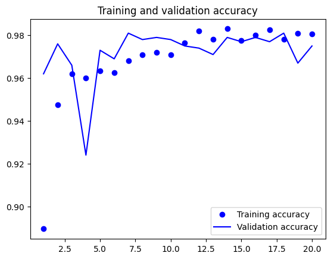

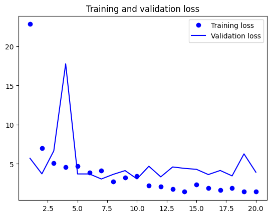

```python
acc = history.history["accuracy"]
val_acc = history.history["val_accuracy"]
loss = history.history["loss"]
val_loss = history.history["val_loss"]
epochs = range(1, len(acc) + 1)
plt.plot(epochs, acc, "bo", label="Training accuracy")
plt.plot(epochs, val_acc, "b", label="Validation accuracy")
plt.title("Training and validation accuracy")
plt.legend()
plt.figure()
plt.plot(epochs, loss, "bo", label="Training loss")
plt.plot(epochs, val_loss, "b", label="Validation loss")
plt.title("Training and validation loss")
plt.legend()
plt.show()
```

**Evaluating the model on the test set**

```python
test_model = keras.models.load_model(
    "./models/feature_extraction_with_data_augmentation.keras")
test_loss, test_acc = test_model.evaluate(test_dataset)
print(f"Test accuracy: {test_acc:.3f}")
```

```
Test accuracy: 0.973
```

### 3.2.4 Fine-tuning a pretrained model

```python
conv_base.summary()
```

```
Model: "vgg16"
_________________________________________________________________
 Layer (type)                Output Shape              Param #
=================================================================
 input_4 (InputLayer)        [(None, None, None, 3)]   0

 block1_conv1 (Conv2D)       (None, None, None, 64)    1792

 block1_conv2 (Conv2D)       (None, None, None, 64)    36928

 block1_pool (MaxPooling2D)  (None, None, None, 64)    0

 block2_conv1 (Conv2D)       (None, None, None, 128)   73856
_________________________________________________________________
 Layer (type)                Output Shape              Param #
=================================================================
 input_4 (InputLayer)        [(None, None, None, 3)]   0

 block1_conv1 (Conv2D)       (None, None, None, 64)    1792

 block1_conv2 (Conv2D)       (None, None, None, 64)    36928

 block1_pool (MaxPooling2D)  (None, None, None, 64)    0

 block2_conv1 (Conv2D)       (None, None, None, 128)   73856

 block2_conv2 (Conv2D)       (None, None, None, 128)   147584

 block2_pool (MaxPooling2D)  (None, None, None, 128)   0

 block3_conv1 (Conv2D)       (None, None, None, 256)   295168

 block3_conv2 (Conv2D)       (None, None, None, 256)   590080

 block3_conv3 (Conv2D)       (None, None, None, 256)   590080

 block3_pool (MaxPooling2D)  (None, None, None, 256)   0

 block4_conv1 (Conv2D)       (None, None, None, 512)   1180160

 block4_conv2 (Conv2D)       (None, None, None, 512)   2359808

 block4_conv3 (Conv2D)       (None, None, None, 512)   2359808

 block4_pool (MaxPooling2D)  (None, None, None, 512)   0

 block5_conv1 (Conv2D)       (None, None, None, 512)   2359808

 block5_conv2 (Conv2D)       (None, None, None, 512)   2359808

 block5_conv3 (Conv2D)       (None, None, None, 512)   2359808

 block5_pool (MaxPooling2D)  (None, None, None, 512)   0

=================================================================
Total params: 14,714,688
Trainable params: 0
Non-trainable params: 14,714,688
_________________________________________________________________
```

```python
conv_base.trainable = True
for layer in conv_base.layers[:-6]:
    layer.trainable = False
```

```python
model.summary()
```

```
Model: "model_2"
_________________________________________________________________
 Layer (type)                Output Shape              Param #
=================================================================
 input_5 (InputLayer)        [(None, 180, 180, 3)]     0

 sequential (Sequential)     (None, 180, 180, 3)       0

 tf.__operators__.getitem (S  (None, 180, 180, 3)      0
 licingOpLambda)

 tf.nn.bias_add (TFOpLambda)  (None, 180, 180, 3)      0

 vgg16 (Functional)          (None, None, None, 512)   14714688

 flatten_2 (Flatten)         (None, 12800)             0

 dense_3 (Dense)             (None, 256)               3277056

 dropout_2 (Dropout)         (None, 256)               0
_________________________________________________________________
 Layer (type)                Output Shape              Param #
=================================================================
 input_5 (InputLayer)        [(None, 180, 180, 3)]     0

 sequential (Sequential)     (None, 180, 180, 3)       0

 tf.__operators__.getitem (S  (None, 180, 180, 3)      0
 licingOpLambda)

 tf.nn.bias_add (TFOpLambda)  (None, 180, 180, 3)      0

 vgg16 (Functional)          (None, None, None, 512)   14714688

 flatten_2 (Flatten)         (None, 12800)             0

 dense_3 (Dense)             (None, 256)               3277056

 dropout_2 (Dropout)         (None, 256)               0

 dense_4 (Dense)             (None, 1)                 257

=================================================================
Total params: 17,992,001
Trainable params: 12,716,545
Non-trainable params: 5,275,456
_________________________________________________________________
```

Running the following cell on a CPU might take 4 hours.

```python
model.compile(loss="binary_crossentropy",
              optimizer=keras.optimizers.RMSprop(learning_rate=1e-5),
              metrics=["accuracy"])

callbacks = [
    keras.callbacks.ModelCheckpoint(
        filepath="./models/fine_tuning.keras",
        save_best_only=True,
        monitor="val_loss")
]
history = model.fit(
    train_dataset,
    epochs=30,
    validation_data=validation_dataset,
    callbacks=callbacks)
```

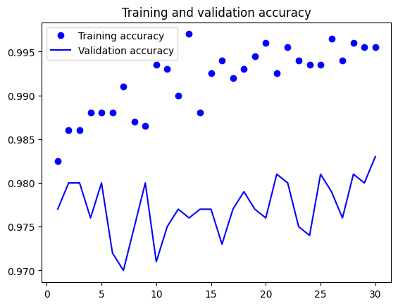

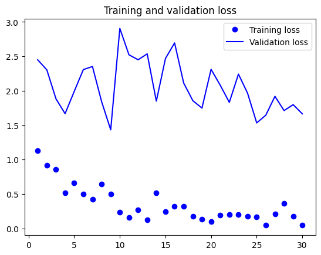

```python
acc = history.history["accuracy"]
val_acc = history.history["val_accuracy"]
loss = history.history["loss"]
val_loss = history.history["val_loss"]
epochs = range(1, len(acc) + 1)
plt.plot(epochs, acc, "bo", label="Training accuracy")
plt.plot(epochs, val_acc, "b", label="Validation accuracy")
plt.title("Training and validation accuracy")
plt.legend()
plt.figure()
plt.plot(epochs, loss, "bo", label="Training loss")
plt.plot(epochs, val_loss, "b", label="Validation loss")
plt.title("Training and validation loss")
plt.legend()
plt.show()
```

```python
model = keras.models.load_model("./models/fine_tuning.keras")
test_loss, test_acc = model.evaluate(test_dataset)
print(f"Test accuracy: {test_acc:.3f}")
```

```
Test accuracy: 0.978
```

## 4 Explore the relative performance of the models (make sure to load the best version of each model)

```python
from tensorflow.keras.models import load_model

convnet_model = load_model("./models/convnet_from_scratch.keras")
feature_extraction_model = load_model("./models/feature_extraction.keras")
feature_extraction_aug_model = load_model("./models/feature_extraction_with_data_augmentation.keras")
fine_tuned_model = load_model("./models/fine_tuning.keras")
```

### 4.1 Accuracy

```python
convnet_acc = convnet_model.evaluate(test_dataset)[1]
feature_extraction_aug_acc = feature_extraction_aug_model.evaluate(test_dataset)[1]
fine_tuned_acc = fine_tuned_model.evaluate(test_dataset)[1]
feature_extraction_acc = feature_extraction_model.evaluate(test_features, test_labels)[1]
```

### 4.2 Confusion matrix , classification_report, precision_recall_curve

```
Evaluating model on ConvNet:
Confusion Matrix:
[[796 204]
 [304 696]]

Classification Report:
              precision    recall  f1-score   support

           0       0.72      0.80      0.76      1000
           1       0.77      0.70      0.73      1000

    accuracy                           0.75      2000
   macro avg       0.75      0.75      0.75      2000
weighted avg       0.75      0.75      0.75      2000
```

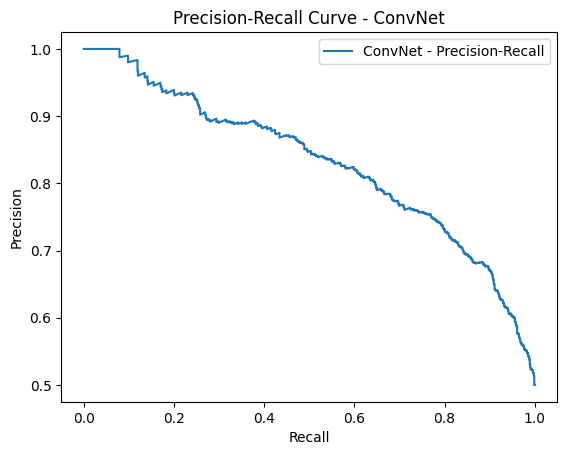

```
Evaluating model on Feature Extraction:
Confusion Matrix:
[[956  44]
 [ 30 970]]

Classification Report:
              precision    recall  f1-score   support

           0       0.97      0.96      0.96      1000
           1       0.96      0.97      0.96      1000

    accuracy                           0.96      2000
   macro avg       0.96      0.96      0.96      2000
weighted avg       0.96      0.96      0.96      2000
```

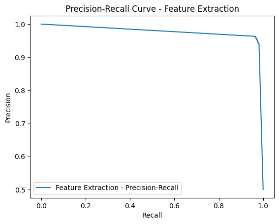

```
Evaluating model on Feature Extraction with Augmentation:
Confusion Matrix:
[[979  21]
 [ 34 966]]

Classification Report:
              precision    recall  f1-score   support

           0       0.97      0.98      0.97      1000
           1       0.98      0.97      0.97      1000

    accuracy                           0.97      2000
   macro avg       0.97      0.97      0.97      2000
weighted avg       0.97      0.97      0.97      2000
```

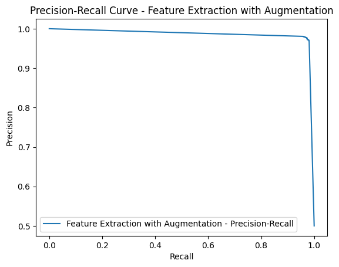

```
Evaluating model on Fine-Tuned Model:
Confusion Matrix:
[[978  22]
 [ 23 977]]

Classification Report:
              precision    recall  f1-score   support

           0       0.98      0.98      0.98      1000
           1       0.98      0.98      0.98      1000

    accuracy                           0.98      2000
   macro avg       0.98      0.98      0.98      2000
weighted avg       0.98      0.98      0.98      2000
```

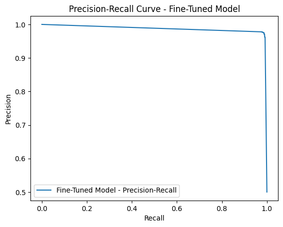

```python
from sklearn.metrics import precision_recall_curve, classification_report, confusion_matrix
import matplotlib.pyplot as plt
import numpy as np

# Load the best models
from tensorflow.keras.models import load_model

convnet_model = load_model("./models/convnet_from_scratch.keras")
feature_extraction_model = load_model("./models/feature_extraction.keras")
feature_extraction_aug_model = load_model("./models/feature_extraction_with_data_augmentation.keras")
fine_tuned_model = load_model("./models/fine_tuning.keras")

# Predictions and evaluation
def evaluate_model(model, dataset, true_labels, dataset_type="test_dataset"):
    print(f"\nEvaluating model on {dataset_type}:")
    # Get predictions (probabilities)
    if dataset_type == "test_dataset":
        probs = model.predict(dataset).ravel()
    else:  # test_features and test_labels
        probs = model.predict(dataset).ravel()
    preds = np.round(probs)  # Convert to binary labels

    # Classification metrics
    print("Confusion Matrix:")
    print(confusion_matrix(true_labels, preds))
    print("\nClassification Report:")
    print(classification_report(true_labels, preds))

    # Precision-Recall curve
    precision, recall, _ = precision_recall_curve(true_labels, probs)
    plt.plot(recall, precision, label=f"{dataset_type} - Precision-Recall")
    plt.xlabel("Recall")
    plt.ylabel("Precision")
    plt.title(f"Precision-Recall Curve - {dataset_type}")
    plt.legend()
    plt.show()

# Evaluate each model

# ConvNet from Scratch
evaluate_model(convnet_model, test_dataset, test_labels, "ConvNet")

# Feature Extraction
evaluate_model(feature_extraction_model, test_features, test_labels, "Feature Extraction")

# Feature Extraction with Data Augmentation
evaluate_model(feature_extraction_aug_model, test_dataset, test_labels, "Feature Extraction with Augmentation")

# Fine-Tuning
evaluate_model(fine_tuned_model, test_dataset, test_labels, "Fine-Tuned Model")
```

# Conclusion

## Data and Setup

- **Dataset Distribution:**
  - Training set: 1000 cat images and 1000 dog images.
  - Validation set: 500 cat images and 500 dog images.
  - Test set: 1000 cat images and 1000 dog images.
- **Image Statistics:**
  - Mean pixel value: 114.03
  - Standard deviation: 65.50

  These metrics are fundamental for understanding the preprocessing and normalization needs.

## Model Performance Overview

### 1. Custom ConvNet Architecture

- **Test Accuracy:** 74.6%
- **Confusion Matrix:**
  - **Class 0:** 796 correctly classified, 204 misclassified.
  - **Class 1:** 696 correctly classified, 304 misclassified.
- **Classification Report:**
  - **Class 0:** Precision = 0.72, Recall = 0.80, F1-score ≈ 0.76
  - **Class 1:** Precision = 0.77, Recall = 0.70, F1-score ≈ 0.73
- **Insight:**  
  This baseline model shows a relatively high rate of misclassifications, indicating that a simple architecture does not capture the complex features as effectively.

### 2. VGG16 using Feature Extraction

- **Test Accuracy:** 96.3%
- **Confusion Matrix:**
  - Significantly fewer misclassifications (only 44 and 30 errors for the two classes).
- **Classification Report:**
  - Both classes have precision and recall values in the range of 0.96–0.97, with F1-scores around 0.96.
- **Insight:**  
  Leveraging a pre-trained model via feature extraction dramatically improves performance by utilizing learned representations from larger datasets.

### 3. VGG16 with Data Augmentation (Feature Extraction)

- **Test Accuracy:** 97%
- **Confusion Matrix:**
  - Further reduction in errors: One class shows 979 correct vs. 21 errors, and the other 966 correct vs. 34 errors.
- **Classification Report:**
  - Both classes exhibit slight improvements in precision and recall (approximately 0.97–0.98), which leads to balanced performance.
- **Insight:**  
  Data augmentation aids in improving generalization, which reduces overfitting and slightly enhances overall accuracy.

### 4. Fine-Tuned VGG16 Model

- **Test Accuracy:** 97.8%
- **Confusion Matrix:**
  - Best performance with only 22 and 23 misclassifications for classes 0 and 1, respectively.
- **Classification Report:**
  - Both classes achieve precision, recall, and F1-scores of approximately 0.98.
- **Insight:**  
  Fine-tuning the pre-trained VGG16 network allows it to adapt more closely to the specific features of the dataset, resulting in the highest accuracy and best balanced performance across all metrics.

## Final Conclusion and Recommendations

- **Comparison of Approaches:**
  - The custom ConvNet reached a 74.6% accuracy, substantially lower than models leveraging transfer learning.
  - Among the VGG16-based models, there is a clear performance hierarchy:
    1. **Feature Extraction:** 96.3% accuracy.
    2. **Feature Extraction with Augmentation:** 97% accuracy.
    3. **Fine-Tuned VGG16:** 97.8% accuracy.
- **Key Performance Metrics:**
  - **Accuracy:** Improved from 74.6% (ConvNet) to 97.8% (Fine-Tuned VGG16).
  - **Precision, Recall, F1-Score:** The fine-tuned model shows balanced metrics (all around 0.98), indicating reliable classification for both classes.
  - **Confusion Matrix:** A clear reduction in false positives and false negatives is observed as the model complexity increases, especially with fine-tuning.